# RPC-PI Experiment - Reliability and Failure Analysis

2026-07-04

# 1 Objective

This R Markdown analyzes **pipeline reliability and failures**.

The main questions are:

```
Which stages completed successfully?
Which scenario/seed runs failed or were retried?
Are there missing metadata files or missing output files?
Are there malformed JSONL event lines?
Where do error.txt files appear?
Which failures are training, inference, metrics, pairwise, or error-analysis failures?
```

This report focuses on operational reliability, not model quality.

It uses logs from:

```
training
inference
metrics
pairwise_metrics
statistical_analysis
error_analysis
```

# 2 Expected folder structure

This Rmd expects logs in one of these locations:

```
data/logs/
logs/
```

If `logs.zip` exists in the project root or inside `data/`, this Rmd tries to extract it automatically to `data/`.

# 3 Paths

```r
OUT_TABLE_DIR <- here::here("tables", "reliability_failure_analysis")
OUT_FIG_DIR <- here::here("figures", "reliability_failure_analysis")

fs::dir_create(OUT_TABLE_DIR)
fs::dir_create(OUT_FIG_DIR)

# Try to extract logs.zip automatically if needed.
if (!dir.exists(here::here("data", "logs")) && file.exists(here::here("logs.zip"))) {
  dir.create(here::here("data"), showWarnings = FALSE)
  unzip(here::here("logs.zip"), exdir = here::here("data"))
}

if (!dir.exists(here::here("data", "logs")) && file.exists(here::here("data", "logs.zip"))) {
  dir.create(here::here("data"), showWarnings = FALSE)
  unzip(here::here("data", "logs.zip"), exdir = here::here("data"))
}

candidate_logs_dirs <- c(
  here::here("data", "logs"),
  here::here("logs")
)

LOGS_DIR <- candidate_logs_dirs[dir.exists(candidate_logs_dirs)][1]

if (is.na(LOGS_DIR)) {
  stop(
    "Could not find logs directory. Expected one of:\n",
    paste(candidate_logs_dirs, collapse = "\n"),
    "\nOr place logs.zip in the project root or data/."
  )
}
```

# 4 Helper functions

```r
`%||%` <- function(x, y) {
  if (is.null(x) || length(x) == 0) y else x
}

scenario_order <- c(
  "c0_base",
  "c1_struq_format_only",
  "c2_struq_sft",
  "c3_secalign_dpo",
  "c4_ih_sft"
)

scenario_labels <- tibble(
  scenario_id = scenario_order,
  scenario_short = c("C0", "C1", "C2", "C3", "C4"),
  scenario_label = c(
    "C0 - Base model",
    "C1 - StruQ format-only",
    "C2 - StruQ-like SFT",
    "C3 - SecAlign-like DPO",
    "C4 - Instruction-Hierarchy-like SFT"
  )
)

scenario_palette <- c(
  C0 = "#7F7F7F",
  C1 = "#D55E00",
  C2 = "#0072B2",
  C3 = "#CC79A7",
  C4 = "#009E73"
)

stage_order <- c(
  "training",
  "inference",
  "metrics",
  "pairwise_metrics",
  "statistical_analysis",
  "error_analysis"
)

stage_labels <- c(
  training = "Training",
  inference = "Inference",
  metrics = "Metrics",
  pairwise_metrics = "Pairwise metrics",
  statistical_analysis = "Statistical analysis",
  error_analysis = "Error analysis"
)

stage_palette <- c(
  training = "#0072B2",
  inference = "#009E73",
  metrics = "#E69F00",
  pairwise_metrics = "#CC79A7",
  statistical_analysis = "#56B4E9",
  error_analysis = "#D55E00"
)

sort_scenarios <- function(df) {
  df |>
    mutate(
      scenario_id = factor(as.character(scenario_id), levels = scenario_order),
      scenario_short = factor(as.character(scenario_short), levels = c("C0", "C1", "C2", "C3", "C4"))
    ) |>
    arrange(scenario_id)
}

sort_stages <- function(df) {
  df |>
    mutate(
      stage = factor(as.character(stage), levels = stage_order),
      stage_label = factor(
        ifelse(
          is.na(stage_labels[as.character(stage)]),
          as.character(stage),
          stage_labels[as.character(stage)]
        ),
        levels = stage_labels[stage_order]
      )
    ) |>
    arrange(stage)
}

add_scenario_info <- function(df) {
  if (!("scenario_id" %in% names(df))) {
    df$scenario_id <- NA_character_
  }

  out <- df |>
    mutate(scenario_id = as.character(scenario_id)) |>
    left_join(scenario_labels, by = "scenario_id", suffix = c("", "_lookup"))

  if (!("scenario_label" %in% names(out))) {
    out$scenario_label <- out$scenario_id
  }

  if ("scenario_label_lookup" %in% names(out)) {
    out <- out |>
      mutate(
        scenario_label = coalesce(
          as.character(scenario_label),
          as.character(scenario_label_lookup)
        )
      )
  }

  if (!("scenario_short" %in% names(out))) {
    out$scenario_short <- NA_character_
  }

  if ("scenario_short_lookup" %in% names(out)) {
    out <- out |>
      mutate(
        scenario_short = coalesce(
          as.character(scenario_short),
          as.character(scenario_short_lookup)
        )
      )
  }

  out |>
    mutate(
      scenario_short = ifelse(
        is.na(scenario_short),
        recode(
          as.character(scenario_id),
          c0_base = "C0",
          c1_struq_format_only = "C1",
          c2_struq_sft = "C2",
          c3_secalign_dpo = "C3",
          c4_ih_sft = "C4",
          .default = as.character(scenario_id)
        ),
        scenario_short
      )
    ) |>
    select(-any_of(c("scenario_label_lookup", "scenario_short_lookup"))) |>
    sort_scenarios()
}

parse_time_utc <- function(x) {
  lubridate::ymd_hms(x, tz = "UTC", quiet = TRUE)
}

normalize_path_for_match <- function(path) {
  stringr::str_replace_all(as.character(path), "\\\\", "/")
}

fmt_number <- function(x, accuracy = 0.01) {
  scales::number(x, accuracy = accuracy, big.mark = ",")
}

fmt_pct <- function(x, accuracy = 0.1) {
  scales::percent(x, accuracy = accuracy)
}

fmt_duration <- function(seconds) {
  ifelse(
    is.na(seconds),
    NA_character_,
    paste0(
      floor(seconds / 3600), "h ",
      floor((seconds %% 3600) / 60), "m ",
      round(seconds %% 60), "s"
    )
  )
}

base_theme <- function(base_size = 12) {
  theme_minimal(base_size = base_size) +
    theme(
      legend.position = "bottom",
      plot.title.position = "plot",
      plot.title = element_text(face = "bold"),
      plot.subtitle = element_text(color = "grey30"),
      panel.grid.minor = element_blank(),
      axis.title = element_text(face = "bold")
    )
}

value_to_text <- function(value) {
  if (is.null(value) || length(value) == 0) {
    return(NA_character_)
  }

  tryCatch(
    as.character(jsonlite::toJSON(value, auto_unbox = TRUE, null = "null")),
    error = function(e) paste(capture.output(str(value)), collapse = " ")
  )
}

replace_null_columns <- function(x) {
  if (!is.list(x)) {
    return(x)
  }

  n <- 1

  non_null_lengths <- purrr::map_int(
    x,
    function(value) {
      if (is.null(value)) {
        0L
      } else if (is.data.frame(value)) {
        nrow(value)
      } else {
        length(value)
      }
    }
  )

  if (any(non_null_lengths > 0)) {
    n <- max(non_null_lengths)
  }

  purrr::map(
    x,
    function(value) {
      if (is.null(value)) {
        rep(NA_character_, n)
      } else {
        value
      }
    }
  )
}

as_tibble_json_safe <- function(x) {
  if (is.null(x)) {
    return(tibble())
  }

  if (is.data.frame(x)) {
    x <- replace_null_columns(x)
    return(tibble::as_tibble(x))
  }

  if (is.list(x)) {
    x <- replace_null_columns(x)
    return(tibble::as_tibble(x))
  }

  tibble(value = x)
}

sanitize_for_csv <- function(df) {
  df <- as_tibble(df)
  n_rows <- nrow(df)

  for (nm in names(df)) {
    col <- df[[nm]]

    if (is.data.frame(col)) {
      if (nrow(col) == n_rows) {
        df[[nm]] <- purrr::map_chr(
          seq_len(n_rows),
          function(i) value_to_text(as.list(col[i, , drop = FALSE]))
        )
      } else {
        df[[nm]] <- rep(value_to_text(col), n_rows)
      }
    } else if (is.matrix(col) || is.array(col)) {
      mat <- as.matrix(col)

      if (nrow(mat) == n_rows) {
        df[[nm]] <- apply(
          mat,
          1,
          function(row) paste(as.character(row), collapse = " | ")
        )
      } else {
        df[[nm]] <- rep(value_to_text(mat), n_rows)
      }
    } else if (is.list(col)) {
      if (length(col) == n_rows) {
        df[[nm]] <- purrr::map_chr(col, value_to_text)
      } else if (length(col) == 1) {
        df[[nm]] <- rep(value_to_text(col[[1]]), n_rows)
      } else {
        df[[nm]] <- rep(value_to_text(col), n_rows)
      }
    }
  }

  df
}

write_rel_csv <- function(df, filename) {
  safe_df <- sanitize_for_csv(df)
  readr::write_csv(safe_df, file.path(OUT_TABLE_DIR, filename))
  invisible(df)
}

safe_count_by_stage <- function(df, count_name) {
  if (is.null(df) || nrow(df) == 0 || !("stage" %in% names(df))) {
    out <- tibble(stage = character(), n = integer())
  } else {
    out <- df |>
      count(stage, name = "n")
  }

  names(out)[names(out) == "n"] <- count_name
  out
}

save_rel_figure <- function(plot, filename, width = 10, height = 6) {
  ggsave(
    file.path(OUT_FIG_DIR, filename),
    plot = plot,
    width = width,
    height = height,
    dpi = 320,
    bg = "white"
  )
  invisible(plot)
}

read_jsonl_robust <- function(path, stage_name) {
  if (!file.exists(path)) {
    return(list(events = tibble(), bad_lines = tibble()))
  }

  lines <- readLines(path, warn = FALSE, encoding = "UTF-8")

  if (length(lines) == 0) {
    return(list(events = tibble(), bad_lines = tibble()))
  }

  parsed <- vector("list", length(lines))
  bad_lines <- list()

  for (i in seq_along(lines)) {
    line <- lines[[i]]

    if (is.na(line) || trimws(line) == "") {
      next
    }

    obj <- tryCatch(
      jsonlite::fromJSON(line, flatten = TRUE),
      error = function(e) {
        bad_lines[[length(bad_lines) + 1]] <<- tibble(
          stage = stage_name,
          line_number = i,
          error = conditionMessage(e),
          line_prefix = substr(line, 1, 300)
        )
        NULL
      }
    )

    if (!is.null(obj)) {
      parsed[[i]] <- as_tibble_json_safe(obj)
    }
  }

  parsed <- parsed[!vapply(parsed, is.null, logical(1))]

  events <- if (length(parsed) == 0) {
    tibble()
  } else {
    dplyr::bind_rows(parsed) |>
      mutate(stage = stage_name, .before = 1)
  }

  bad <- dplyr::bind_rows(bad_lines)

  list(events = events, bad_lines = bad)
}

read_json_safe <- function(path) {
  tryCatch(
    jsonlite::fromJSON(path, flatten = TRUE),
    error = function(e) NULL
  )
}

get_scalar <- function(obj, field, default = NA) {
  value <- obj[[field]]

  if (is.null(value) || length(value) == 0) {
    return(default)
  }

  if (is.data.frame(value)) {
    if (nrow(value) == 0 || ncol(value) == 0) return(default)
    return(value[[1]][[1]])
  }

  if (is.list(value) && length(value) == 1 && !is.null(value[[1]])) {
    return(value[[1]])
  }

  value[[1]]
}

classify_error_text <- function(error_text) {
  txt <- tolower(error_text)

  case_when(
    str_detect(txt, "cuda|out of memory|oom|memory") ~ "resource_or_memory",
    str_detect(txt, "deploymentnotfound|404|not found") ~ "missing_resource_or_deployment",
    str_detect(txt, "timeout|timed out|deadline") ~ "timeout",
    str_detect(txt, "rate limit|429|quota") ~ "rate_limit_or_quota",
    str_detect(txt, "json|parse|premature eof|invalid") ~ "parse_or_json",
    str_detect(txt, "authentication|unauthorized|permission|forbidden|401|403") ~ "auth_or_permission",
    str_detect(txt, "connection|network|dns|ssl|tls") ~ "network",
    str_detect(txt, "assert|expected|validation") ~ "validation_or_assertion",
    TRUE ~ "other"
  )
}

safe_status_group <- function(status) {
  status_chr <- tolower(as.character(status))

  case_when(
    is.na(status_chr) | status_chr == "" ~ "unknown",
    str_detect(status_chr, "complete|success|ok") ~ "completed",
    str_detect(status_chr, "fail|error|exception|crash") ~ "failed",
    str_detect(status_chr, "skip") ~ "skipped",
    str_detect(status_chr, "start|running|progress") ~ "running_or_started",
    TRUE ~ "other"
  )
}
```

# 5 Discover stage files

```r
stage_paths <- tibble(
  stage = stage_order,
  stage_label = stage_labels[stage_order],
  stage_dir = file.path(LOGS_DIR, stage_order)
) |>
  mutate(
    dir_exists = dir.exists(stage_dir),
    event_path = case_when(
      stage == "training" ~ file.path(stage_dir, "04_run_training_events.jsonl"),
      stage == "inference" ~ file.path(stage_dir, "05_run_inference_events.jsonl"),
      stage == "metrics" ~ file.path(stage_dir, "06_compute_metrics_events.jsonl"),
      stage == "pairwise_metrics" ~ file.path(stage_dir, "07_pairwise_and_injected_metrics_events.jsonl"),
      stage == "statistical_analysis" ~ file.path(stage_dir, "08_statistical_analysis_events.jsonl"),
      stage == "error_analysis" ~ file.path(stage_dir, "09_error_analysis_events.jsonl"),
      TRUE ~ NA_character_
    ),
    summary_path = case_when(
      stage == "training" ~ file.path(stage_dir, "04_run_training_summary.json"),
      stage == "inference" ~ file.path(stage_dir, "05_run_inference_summary.json"),
      stage == "metrics" ~ file.path(stage_dir, "06_compute_metrics_summary_full.json"),
      stage == "pairwise_metrics" ~ file.path(stage_dir, "07_pairwise_and_injected_metrics_summary.json"),
      stage == "statistical_analysis" ~ file.path(stage_dir, "08_statistical_analysis_summary_full.json"),
      stage == "error_analysis" ~ file.path(stage_dir, "09_error_analysis_summary.json"),
      TRUE ~ NA_character_
    ),
    event_exists = file.exists(event_path),
    summary_exists = file.exists(summary_path)
  ) |>
  sort_stages()

write_rel_csv(stage_paths, "01_stage_file_inventory.csv")

stage_paths |>
  knitr::kable(
    caption = "Table 1 - Stage file inventory."
  )
```

Table 1 - Stage file inventory.

| stage | stage_label | stage_dir | dir_exists | event_path | summary_path | event_exists | summary_exists |
| --- | --- | --- | --- | --- | --- | --- | --- |
| training | Training | D:/LETICIA/UFCG/RPC/RPC-PI-EXPERIMENT/pi-defense-analysis/data/logs/training | TRUE | D:/LETICIA/UFCG/RPC/RPC-PI-EXPERIMENT/pi-defense-analysis/data/logs/training/04_run_training_events.jsonl | D:/LETICIA/UFCG/RPC/RPC-PI-EXPERIMENT/pi-defense-analysis/data/logs/training/04_run_training_summary.json | TRUE | TRUE |
| inference | Inference | D:/LETICIA/UFCG/RPC/RPC-PI-EXPERIMENT/pi-defense-analysis/data/logs/inference | TRUE | D:/LETICIA/UFCG/RPC/RPC-PI-EXPERIMENT/pi-defense-analysis/data/logs/inference/05_run_inference_events.jsonl | D:/LETICIA/UFCG/RPC/RPC-PI-EXPERIMENT/pi-defense-analysis/data/logs/inference/05_run_inference_summary.json | TRUE | TRUE |
| metrics | Metrics | D:/LETICIA/UFCG/RPC/RPC-PI-EXPERIMENT/pi-defense-analysis/data/logs/metrics | TRUE | D:/LETICIA/UFCG/RPC/RPC-PI-EXPERIMENT/pi-defense-analysis/data/logs/metrics/06_compute_metrics_events.jsonl | D:/LETICIA/UFCG/RPC/RPC-PI-EXPERIMENT/pi-defense-analysis/data/logs/metrics/06_compute_metrics_summary_full.json | TRUE | TRUE |
| pairwise_metrics | Pairwise metrics | D:/LETICIA/UFCG/RPC/RPC-PI-EXPERIMENT/pi-defense-analysis/data/logs/pairwise_metrics | TRUE | D:/LETICIA/UFCG/RPC/RPC-PI-EXPERIMENT/pi-defense-analysis/data/logs/pairwise_metrics/07_pairwise_and_injected_metrics_events.jsonl | D:/LETICIA/UFCG/RPC/RPC-PI-EXPERIMENT/pi-defense-analysis/data/logs/pairwise_metrics/07_pairwise_and_injected_metrics_summary.json | TRUE | TRUE |
| statistical_analysis | Statistical analysis | D:/LETICIA/UFCG/RPC/RPC-PI-EXPERIMENT/pi-defense-analysis/data/logs/statistical_analysis | TRUE | D:/LETICIA/UFCG/RPC/RPC-PI-EXPERIMENT/pi-defense-analysis/data/logs/statistical_analysis/08_statistical_analysis_events.jsonl | D:/LETICIA/UFCG/RPC/RPC-PI-EXPERIMENT/pi-defense-analysis/data/logs/statistical_analysis/08_statistical_analysis_summary_full.json | TRUE | TRUE |
| error_analysis | Error analysis | D:/LETICIA/UFCG/RPC/RPC-PI-EXPERIMENT/pi-defense-analysis/data/logs/error_analysis | TRUE | D:/LETICIA/UFCG/RPC/RPC-PI-EXPERIMENT/pi-defense-analysis/data/logs/error_analysis/09_error_analysis_events.jsonl | D:/LETICIA/UFCG/RPC/RPC-PI-EXPERIMENT/pi-defense-analysis/data/logs/error_analysis/09_error_analysis_summary.json | TRUE | TRUE |

# 6 Load and validate event logs

```r
event_read_results <- purrr::map2(
  stage_paths$event_path,
  stage_paths$stage,
  read_jsonl_robust
)

all_events <- purrr::map_dfr(event_read_results, "events")
bad_jsonl_lines <- purrr::map_dfr(event_read_results, "bad_lines")

if (!("stage" %in% names(all_events))) {
  all_events <- tibble(stage = character())
}

if (!("stage" %in% names(bad_jsonl_lines))) {
  bad_jsonl_lines <- tibble(
    stage = character(),
    line_number = integer(),
    error = character(),
    line_prefix = character()
  )
}

if (nrow(all_events) > 0) {
  if (!("scenario_id" %in% names(all_events)) && "scenario" %in% names(all_events)) {
    all_events <- all_events |>
      rename(scenario_id = scenario)
  } else if ("scenario" %in% names(all_events)) {
    all_events <- all_events |>
      mutate(
        scenario_id = coalesce(
          as.character(scenario_id),
          as.character(scenario)
        )
      )
  }

  if (!("seed" %in% names(all_events))) {
    all_events$seed <- NA_integer_
  }

  if (!("event_type" %in% names(all_events))) {
    all_events$event_type <- NA_character_
  }

  if (!("timestamp_utc" %in% names(all_events))) {
    all_events$timestamp_utc <- NA_character_
  }

  if (!("status" %in% names(all_events))) {
    all_events$status <- NA_character_
  }

  if (!("elapsed_seconds" %in% names(all_events))) {
    all_events$elapsed_seconds <- NA_real_
  }

  if (!("rows" %in% names(all_events))) {
    all_events$rows <- NA_real_
  }

  all_events <- all_events |>
    mutate(
      stage = as.character(stage),
      event_type = as.character(event_type),
      timestamp = parse_time_utc(timestamp_utc),
      scenario_id = as.character(scenario_id),
      seed = suppressWarnings(as.integer(seed)),
      status = as.character(status),
      status_group = safe_status_group(status),
      elapsed_seconds = suppressWarnings(as.numeric(elapsed_seconds)),
      rows = suppressWarnings(as.numeric(rows)),
      event_has_error_signal = str_detect(
        tolower(paste(event_type, status, sep = " ")),
        "error|fail|exception|crash"
      )
    ) |>
    add_scenario_info() |>
    sort_stages()
} else {
  all_events <- tibble(
    stage = character(),
    event_type = character(),
    timestamp_utc = character(),
    timestamp = as.POSIXct(character()),
    scenario_id = character(),
    seed = integer(),
    status = character(),
    status_group = character(),
    elapsed_seconds = numeric(),
    rows = numeric(),
    event_has_error_signal = logical()
  )
}

write_rel_csv(all_events, "02_all_events_enriched.csv")
write_rel_csv(bad_jsonl_lines, "03_bad_jsonl_lines.csv")

event_integrity_summary <- stage_paths |>
  select(stage, stage_label, event_exists) |>
  left_join(
    safe_count_by_stage(all_events, "parsed_event_rows"),
    by = "stage"
  ) |>
  left_join(
    safe_count_by_stage(bad_jsonl_lines, "bad_jsonl_lines"),
    by = "stage"
  ) |>
  mutate(
    parsed_event_rows = replace_na(parsed_event_rows, 0L),
    bad_jsonl_lines = replace_na(bad_jsonl_lines, 0L),
    has_bad_jsonl = bad_jsonl_lines > 0
  ) |>
  sort_stages()

write_rel_csv(event_integrity_summary, "04_event_integrity_summary.csv")

event_integrity_summary |>
  knitr::kable(
    caption = "Table 2 - Event integrity summary."
  )
```

Table 2 - Event integrity summary.

| stage | stage_label | event_exists | parsed_event_rows | bad_jsonl_lines | has_bad_jsonl |
| --- | --- | --- | --- | --- | --- |
| training | Training | TRUE | 129 | 0 | FALSE |
| inference | Inference | TRUE | 178 | 0 | FALSE |
| metrics | Metrics | TRUE | 15 | 0 | FALSE |
| pairwise_metrics | Pairwise metrics | TRUE | 135 | 0 | FALSE |
| statistical_analysis | Statistical analysis | TRUE | 5 | 0 | FALSE |
| error_analysis | Error analysis | TRUE | 22 | 0 | FALSE |

```r
if (nrow(bad_jsonl_lines) > 0) {
  bad_jsonl_lines |>
    knitr::kable(
      caption = "Table 3 - Malformed JSONL lines."
    )
} else {
  cat("No malformed JSONL lines found.")
}
```

```
## No malformed JSONL lines found.
```

# 7 Event-level reliability

```r
event_type_summary <- if (nrow(all_events) > 0) {
  all_events |>
    count(stage, stage_label, event_type, status_group, name = "n_events") |>
    group_by(stage, stage_label) |>
    mutate(event_share_within_stage = n_events / sum(n_events)) |>
    ungroup() |>
    sort_stages()
} else {
  tibble()
}

event_scenario_summary <- if (nrow(all_events) > 0) {
  all_events |>
    group_by(stage, stage_label, scenario_id, scenario_short, seed) |>
    summarise(
      n_events = n(),
      n_started_events = sum(str_detect(event_type, "started|start"), na.rm = TRUE),
      n_completed_events = sum(str_detect(event_type, "completed|complete"), na.rm = TRUE),
      n_failed_or_error_events = sum(event_has_error_signal, na.rm = TRUE),
      first_event_utc = min(timestamp, na.rm = TRUE),
      last_event_utc = max(timestamp, na.rm = TRUE),
      observed_seconds = as.numeric(difftime(last_event_utc, first_event_utc, units = "secs")),
      reported_elapsed_seconds_sum = sum(elapsed_seconds, na.rm = TRUE),
      rows_sum = sum(rows, na.rm = TRUE),
      .groups = "drop"
    ) |>
    mutate(
      event_reliability_label = case_when(
        n_failed_or_error_events > 0 ~ "has_error_signal",
        n_started_events > n_completed_events & n_completed_events == 0 ~ "started_without_completion",
        n_started_events > n_completed_events ~ "possible_retry_or_incomplete",
        n_completed_events >= 1 ~ "completed_signal",
        TRUE ~ "no_completion_signal"
      )
    ) |>
    sort_stages() |>
    sort_scenarios()
} else {
  tibble()
}

write_rel_csv(event_type_summary, "05_event_type_summary.csv")
write_rel_csv(event_scenario_summary, "06_event_scenario_seed_summary.csv")

event_type_summary |>
  mutate(event_share_within_stage = fmt_pct(event_share_within_stage)) |>
  knitr::kable(
    caption = "Table 4 - Event type summary by stage."
  )
```

Table 4 - Event type summary by stage.

| stage | stage_label | event_type | status_group | n_events | event_share_within_stage |
| --- | --- | --- | --- | --- | --- |
| training | Training | run_completed | unknown | 108 | 83.7% |
| training | Training | run_failed | unknown | 1 | 0.8% |
| training | Training | run_started | unknown | 20 | 15.5% |
| inference | Inference | run_completed | unknown | 22 | 12.4% |
| inference | Inference | run_failed | unknown | 1 | 0.6% |
| inference | Inference | run_started | unknown | 23 | 12.9% |
| inference | Inference | split_completed | unknown | 66 | 37.1% |
| inference | Inference | split_started | unknown | 66 | 37.1% |
| metrics | Metrics | inference_files_discovered | unknown | 3 | 20.0% |
| metrics | Metrics | inference_results_loaded | unknown | 3 | 20.0% |
| metrics | Metrics | metrics_files_generated | unknown | 3 | 20.0% |
| metrics | Metrics | metrics_manifest_created | unknown | 3 | 20.0% |
| metrics | Metrics | metrics_notebook_started | unknown | 3 | 20.0% |
| pairwise_metrics | Pairwise metrics | injected_only_run_completed | unknown | 16 | 11.9% |
| pairwise_metrics | Pairwise metrics | injected_only_run_failed | unknown | 3 | 2.2% |
| pairwise_metrics | Pairwise metrics | injected_only_run_skipped_existing | unknown | 7 | 5.2% |
| pairwise_metrics | Pairwise metrics | injected_only_run_started | unknown | 22 | 16.3% |
| pairwise_metrics | Pairwise metrics | injected_only_split_completed | completed | 30 | 22.2% |
| pairwise_metrics | Pairwise metrics | injected_only_split_started | unknown | 33 | 24.4% |
| pairwise_metrics | Pairwise metrics | judge_model_loading_completed | unknown | 1 | 0.7% |
| pairwise_metrics | Pairwise metrics | judge_model_loading_started | unknown | 1 | 0.7% |
| pairwise_metrics | Pairwise metrics | win_rate_group_completed | completed | 10 | 7.4% |
| pairwise_metrics | Pairwise metrics | win_rate_group_started | unknown | 10 | 7.4% |
| pairwise_metrics | Pairwise metrics | win_rate_judging_completed | unknown | 1 | 0.7% |
| pairwise_metrics | Pairwise metrics | win_rate_judging_started | unknown | 1 | 0.7% |
| statistical_analysis | Statistical analysis | metrics_06_loaded | unknown | 1 | 20.0% |
| statistical_analysis | Statistical analysis | metrics_07_loaded | unknown | 1 | 20.0% |
| statistical_analysis | Statistical analysis | statistical_analysis_completed | unknown | 1 | 20.0% |
| statistical_analysis | Statistical analysis | statistical_analysis_files_generated | unknown | 1 | 20.0% |
| statistical_analysis | Statistical analysis | statistical_analysis_started | unknown | 1 | 20.0% |
| error_analysis | Error analysis | coverage_table_created | unknown | 1 | 4.5% |
| error_analysis | Error analysis | discussion_tables_created | unknown | 1 | 4.5% |
| error_analysis | Error analysis | failure_taxonomy_created | unknown | 1 | 4.5% |
| error_analysis | Error analysis | inference_outputs_loaded | unknown | 1 | 4.5% |
| error_analysis | Error analysis | invalid_outputs_created | unknown | 1 | 4.5% |
| error_analysis | Error analysis | manifest_created | unknown | 1 | 4.5% |
| error_analysis | Error analysis | manifests_loaded | unknown | 6 | 27.3% |
| error_analysis | Error analysis | notebook_started | unknown | 1 | 4.5% |
| error_analysis | Error analysis | paired_vs_c0_created | unknown | 1 | 4.5% |
| error_analysis | Error analysis | qualitative_samples_created | unknown | 4 | 18.2% |
| error_analysis | Error analysis | qualitative_summary_created | unknown | 1 | 4.5% |
| error_analysis | Error analysis | seen_unseen_analysis_created | unknown | 1 | 4.5% |
| error_analysis | Error analysis | shared_failures_created | unknown | 1 | 4.5% |
| error_analysis | Error analysis | task_and_attack_error_tables_created | unknown | 1 | 4.5% |

```r
event_scenario_summary |>
  select(
    stage_label,
    scenario_short,
    seed,
    n_events,
    n_started_events,
    n_completed_events,
    n_failed_or_error_events,
    observed_seconds,
    reported_elapsed_seconds_sum,
    rows_sum,
    event_reliability_label
  ) |>
  mutate(
    observed_seconds = fmt_number(observed_seconds),
    reported_elapsed_seconds_sum = fmt_number(reported_elapsed_seconds_sum),
    rows_sum = fmt_number(rows_sum, accuracy = 1)
  ) |>
  knitr::kable(
    caption = "Table 5 - Event reliability by scenario and seed."
  )
```

Table 5 - Event reliability by scenario and seed.

| stage_label | scenario_short | seed | n_events | n_started_events | n_completed_events | n_failed_or_error_events | observed_seconds | reported_elapsed_seconds_sum | rows_sum | event_reliability_label |
| --- | --- | --- | --- | --- | --- | --- | --- | --- | --- | --- |
| Inference | C0 | 42 | 18 | 9 | 8 | 1 | 931.34 | 1,173.20 | 33,888 | has_error_signal |
| Pairwise metrics | C0 | 42 | 19 | 9 | 7 | 0 | 3,470.33 | 871.88 | 69,412 | possible_retry_or_incomplete |
| Inference | C1 | 42 | 16 | 8 | 8 | 0 | 1,530.26 | 1,217.01 | 33,888 | completed_signal |
| Pairwise metrics | C1 | 42 | 18 | 8 | 6 | 2 | 3,482.89 | 1,053.20 | 60,032 | has_error_signal |
| Training | C2 | 42 | 15 | 3 | 12 | 0 | 18,070.86 | 16,354.76 | 0 | completed_signal |
| Training | C2 | 123 | 14 | 2 | 12 | 0 | 17,350.76 | 16,442.31 | 0 | completed_signal |
| Training | C2 | 2026 | 14 | 2 | 12 | 0 | 17,313.53 | 16,467.53 | 0 | completed_signal |
| Inference | C2 | 42 | 16 | 8 | 8 | 0 | 2,362.72 | 1,681.44 | 33,888 | completed_signal |
| Inference | C2 | 123 | 16 | 8 | 8 | 0 | 3,191.91 | 1,685.08 | 33,888 | completed_signal |
| Inference | C2 | 2026 | 16 | 8 | 8 | 0 | 4,013.04 | 1,668.60 | 33,888 | completed_signal |
| Pairwise metrics | C2 | 42 | 15 | 7 | 6 | 1 | 2,640.95 | 1,253.25 | 60,032 | has_error_signal |
| Pairwise metrics | C2 | 123 | 13 | 6 | 6 | 0 | 2,399.78 | 1,250.77 | 60,032 | completed_signal |
| Pairwise metrics | C2 | 2026 | 10 | 7 | 3 | 0 | 2,407.73 | 842.79 | 48,776 | possible_retry_or_incomplete |
| Training | C3 | 42 | 16 | 3 | 12 | 1 | 16,770.69 | 10,062.92 | 0 | has_error_signal |
| Training | C3 | 123 | 14 | 2 | 12 | 0 | 12,820.61 | 10,100.46 | 0 | completed_signal |
| Training | C3 | 2026 | 14 | 2 | 12 | 0 | 12,822.09 | 10,079.46 | 0 | completed_signal |
| Inference | C3 | 42 | 16 | 8 | 8 | 0 | 4,835.92 | 1,669.67 | 33,888 | completed_signal |
| Inference | C3 | 123 | 16 | 8 | 8 | 0 | 5,793.28 | 1,939.18 | 33,888 | completed_signal |
| Inference | C3 | 2026 | 16 | 8 | 8 | 0 | 6,685.28 | 1,807.06 | 33,888 | completed_signal |
| Pairwise metrics | C3 | 42 | 6 | 3 | 3 | 0 | 476.32 | 947.01 | 30,016 | completed_signal |
| Pairwise metrics | C3 | 123 | 6 | 3 | 3 | 0 | 530.11 | 1,055.01 | 30,016 | completed_signal |
| Pairwise metrics | C3 | 2026 | 6 | 3 | 3 | 0 | 547.45 | 1,089.45 | 30,016 | completed_signal |
| Training | C4 | 42 | 14 | 2 | 12 | 0 | 13,353.23 | 16,288.29 | 0 | completed_signal |
| Training | C4 | 123 | 14 | 2 | 12 | 0 | 13,364.80 | 16,280.88 | 0 | completed_signal |
| Training | C4 | 2026 | 14 | 2 | 12 | 0 | 13,344.94 | 16,099.15 | 0 | completed_signal |
| Inference | C4 | 42 | 16 | 8 | 8 | 0 | 7,531.21 | 1,715.70 | 33,888 | completed_signal |
| Inference | C4 | 123 | 16 | 8 | 8 | 0 | 8,426.16 | 1,765.69 | 33,888 | completed_signal |
| Inference | C4 | 2026 | 16 | 8 | 8 | 0 | 9,275.53 | 1,722.11 | 33,888 | completed_signal |
| Pairwise metrics | C4 | 42 | 6 | 3 | 3 | 0 | 429.24 | 852.78 | 30,016 | completed_signal |
| Pairwise metrics | C4 | 123 | 6 | 3 | 3 | 0 | 428.38 | 851.39 | 30,016 | completed_signal |
| Pairwise metrics | C4 | 2026 | 6 | 3 | 3 | 0 | 428.63 | 852.10 | 30,016 | completed_signal |
| Metrics | - | - | 15 | 3 | 0 | 0 | 5,712.30 | 0.00 | 0 | started_without_completion |
| Pairwise metrics | - | - | 24 | 12 | 12 | 0 | 718.82 | 943.81 | 3,000 | completed_signal |
| Statistical analysis | - | - | 5 | 1 | 1 | 0 | 0.95 | 0.00 | 0 | completed_signal |
| Error analysis | - | - | 22 | 1 | 0 | 3 | 16.72 | 0.00 | 200,864 | has_error_signal |

# 8 Metadata inventory

```r
all_json_files <- fs::dir_ls(LOGS_DIR, recurse = TRUE, regexp = "\\.json$")

metadata_inventory <- tibble(
  file_path = as.character(all_json_files)
) |>
  mutate(
    stage = case_when(
      str_detect(normalize_path_for_match(file_path), "/training/") ~ "training",
      str_detect(normalize_path_for_match(file_path), "/inference/") ~ "inference",
      str_detect(normalize_path_for_match(file_path), "/metrics/") ~ "metrics",
      str_detect(normalize_path_for_match(file_path), "/pairwise_metrics/") ~ "pairwise_metrics",
      str_detect(normalize_path_for_match(file_path), "/statistical_analysis/") ~ "statistical_analysis",
      str_detect(normalize_path_for_match(file_path), "/error_analysis/") ~ "error_analysis",
      TRUE ~ NA_character_
    ),
    file_name = basename(file_path),
    file_type = case_when(
      file_name == "run_metadata.json" ~ "run_metadata",
      str_detect(file_name, "test_.*_metadata\\.json$") ~ "split_metadata",
      str_detect(file_name, "summary") ~ "summary",
      TRUE ~ "other_json"
    ),
    file_size_bytes = file.info(file_path)$size,
    parse_ok = purrr::map_lgl(
      file_path,
      function(path) !is.null(read_json_safe(path))
    )
  ) |>
  sort_stages()

metadata_inventory_summary <- metadata_inventory |>
  count(stage, stage_label, file_type, parse_ok, name = "n_files") |>
  sort_stages()

write_rel_csv(metadata_inventory, "07_metadata_inventory.csv")
write_rel_csv(metadata_inventory_summary, "08_metadata_inventory_summary.csv")

metadata_inventory_summary |>
  knitr::kable(
    caption = "Table 6 - Metadata inventory summary."
  )
```

Table 6 - Metadata inventory summary.

| stage | stage_label | file_type | parse_ok | n_files |
| --- | --- | --- | --- | --- |
| training | Training | run_metadata | TRUE | 9 |
| training | Training | summary | TRUE | 1 |
| inference | Inference | run_metadata | TRUE | 11 |
| inference | Inference | split_metadata | TRUE | 33 |
| inference | Inference | summary | TRUE | 1 |
| metrics | Metrics | summary | TRUE | 1 |
| pairwise_metrics | Pairwise metrics | run_metadata | TRUE | 21 |
| pairwise_metrics | Pairwise metrics | summary | TRUE | 1 |
| statistical_analysis | Statistical analysis | summary | TRUE | 1 |
| error_analysis | Error analysis | summary | TRUE | 1 |

# 9 Run metadata reliability

```r
run_metadata_files <- metadata_inventory |>
  filter(file_type == "run_metadata", parse_ok) |>
  pull(file_path)

read_run_metadata_minimal <- function(path) {
  obj <- read_json_safe(path)

  if (is.null(obj)) {
    return(tibble(
      metadata_path = path,
      parse_ok = FALSE
    ))
  }

  path_chr <- as.character(path)

  stage <- case_when(
    str_detect(normalize_path_for_match(path_chr), "/training/") ~ "training",
    str_detect(normalize_path_for_match(path_chr), "/inference/") ~ "inference",
    str_detect(normalize_path_for_match(path_chr), "/pairwise_metrics/") ~ "pairwise_metrics",
    TRUE ~ NA_character_
  )

  substage <- case_when(
    str_detect(normalize_path_for_match(path_chr), "/pairwise_metrics/.*/injected_only/") ~ "injected_only",
    str_detect(normalize_path_for_match(path_chr), "/pairwise_metrics/.*/win_rate/") ~ "win_rate",
    TRUE ~ stage
  )

  scenario_id <- as.character(
    get_scalar(
      obj,
      "scenario_id",
      get_scalar(
        obj,
        "scenario",
        get_scalar(obj, "defended_scenario_id", NA_character_)
      )
    )
  )

  seed <- suppressWarnings(as.integer(
    get_scalar(
      obj,
      "seed",
      get_scalar(obj, "defended_seed", NA_integer_)
    )
  ))

  status <- as.character(get_scalar(obj, "status", NA_character_))
  elapsed_seconds <- suppressWarnings(as.numeric(get_scalar(obj, "elapsed_seconds", NA_real_)))

  tibble(
    stage = stage,
    substage = substage,
    scenario_id = scenario_id,
    seed = seed,
    status = status,
    status_group = safe_status_group(status),
    started_at_utc = as.character(get_scalar(obj, "started_at_utc", NA_character_)),
    finished_at_utc = as.character(get_scalar(obj, "finished_at_utc", NA_character_)),
    started_at = parse_time_utc(started_at_utc),
    finished_at = parse_time_utc(finished_at_utc),
    elapsed_seconds = elapsed_seconds,
    rows = suppressWarnings(as.numeric(get_scalar(obj, "rows", NA_real_))),
    train_rows = suppressWarnings(as.numeric(get_scalar(obj, "train_rows", NA_real_))),
    validation_rows = suppressWarnings(as.numeric(get_scalar(obj, "validation_rows", NA_real_))),
    method = as.character(get_scalar(obj, "method", NA_character_)),
    run_mode = as.character(get_scalar(obj, "run_mode", NA_character_)),
    metadata_path = path_chr,
    parse_ok = TRUE
  )
}

run_metadata <- purrr::map_dfr(
  run_metadata_files,
  read_run_metadata_minimal
) |>
  add_scenario_info() |>
  mutate(
    elapsed_minutes = elapsed_seconds / 60,
    has_started_at = !is.na(started_at),
    has_finished_at = !is.na(finished_at),
    has_elapsed_seconds = !is.na(elapsed_seconds),
    elapsed_from_timestamps = as.numeric(difftime(finished_at, started_at, units = "secs")),
    elapsed_mismatch_seconds = elapsed_seconds - elapsed_from_timestamps,
    metadata_issue = case_when(
      status_group == "failed" ~ "failed_status",
      !has_started_at ~ "missing_started_at",
      !has_finished_at ~ "missing_finished_at",
      !has_elapsed_seconds ~ "missing_elapsed_seconds",
      !is.na(elapsed_mismatch_seconds) & abs(elapsed_mismatch_seconds) > 5 ~ "elapsed_timestamp_mismatch",
      TRUE ~ "no_obvious_issue"
    )
  ) |>
  sort_stages() |>
  sort_scenarios()

run_status_summary <- run_metadata |>
  count(stage, stage_label, substage, status_group, status, name = "n_runs") |>
  sort_stages()

run_metadata_issue_summary <- run_metadata |>
  count(stage, stage_label, substage, metadata_issue, name = "n_runs") |>
  sort_stages()

write_rel_csv(run_metadata, "09_run_metadata_reliability.csv")
write_rel_csv(run_status_summary, "10_run_status_summary.csv")
write_rel_csv(run_metadata_issue_summary, "11_run_metadata_issue_summary.csv")

run_status_summary |>
  knitr::kable(
    caption = "Table 7 - Run status summary."
  )
```

Table 7 - Run status summary.

| stage | stage_label | substage | status_group | status | n_runs |
| --- | --- | --- | --- | --- | --- |
| training | Training | training | completed | completed | 9 |
| inference | Inference | inference | completed | completed | 11 |
| pairwise_metrics | Pairwise metrics | injected_only | completed | completed_or_reused | 11 |
| pairwise_metrics | Pairwise metrics | win_rate | completed | completed | 10 |

```r
run_metadata_issue_summary |>
  knitr::kable(
    caption = "Table 8 - Run metadata issue summary."
  )
```

Table 8 - Run metadata issue summary.

| stage | stage_label | substage | metadata_issue | n_runs |
| --- | --- | --- | --- | --- |
| training | Training | training | no_obvious_issue | 9 |
| inference | Inference | inference | no_obvious_issue | 11 |
| pairwise_metrics | Pairwise metrics | injected_only | no_obvious_issue | 11 |
| pairwise_metrics | Pairwise metrics | win_rate | no_obvious_issue | 10 |

# 10 Split metadata reliability

```r
split_metadata_files <- metadata_inventory |>
  filter(file_type == "split_metadata", parse_ok) |>
  pull(file_path)

read_split_metadata_minimal <- function(path) {
  obj <- read_json_safe(path)

  if (is.null(obj)) {
    return(tibble(
      metadata_path = path,
      parse_ok = FALSE
    ))
  }

  path_chr <- as.character(path)

  stage <- case_when(
    str_detect(normalize_path_for_match(path_chr), "/inference/") ~ "inference",
    TRUE ~ NA_character_
  )

  tibble(
    stage = stage,
    scenario_id = as.character(get_scalar(obj, "scenario_id", NA_character_)),
    seed = suppressWarnings(as.integer(get_scalar(obj, "seed", NA_integer_))),
    split = as.character(get_scalar(obj, "split", NA_character_)),
    status = as.character(get_scalar(obj, "status", NA_character_)),
    status_group = safe_status_group(status),
    started_at_utc = as.character(get_scalar(obj, "started_at_utc", NA_character_)),
    finished_at_utc = as.character(get_scalar(obj, "finished_at_utc", NA_character_)),
    started_at = parse_time_utc(started_at_utc),
    finished_at = parse_time_utc(finished_at_utc),
    elapsed_seconds = suppressWarnings(as.numeric(get_scalar(obj, "elapsed_seconds", NA_real_))),
    rows = suppressWarnings(as.numeric(get_scalar(obj, "rows", NA_real_))),
    output_path = as.character(get_scalar(obj, "output_path", NA_character_)),
    normalized_null_count = suppressWarnings(as.numeric(get_scalar(obj, "normalized_null_count", NA_real_))),
    metadata_path = path_chr,
    parse_ok = TRUE
  )
}

split_metadata <- purrr::map_dfr(
  split_metadata_files,
  read_split_metadata_minimal
) |>
  add_scenario_info() |>
  mutate(
    stage = as.character(stage),
    elapsed_minutes = elapsed_seconds / 60,
    output_exists = ifelse(
      is.na(output_path) | output_path == "",
      FALSE,
      file.exists(output_path)
    ),
    normalized_null_rate = normalized_null_count / rows,
    split_issue = case_when(
      status_group == "failed" ~ "failed_status",
      is.na(rows) | rows <= 0 ~ "missing_or_zero_rows",
      is.na(elapsed_seconds) | elapsed_seconds <= 0 ~ "missing_or_zero_elapsed",
      is.na(output_path) | output_path == "" ~ "missing_output_path",
      !output_exists ~ "output_path_not_found",
      !is.na(normalized_null_rate) & normalized_null_rate > 0 ~ "has_normalized_nulls",
      TRUE ~ "no_obvious_issue"
    )
  ) |>
  sort_stages() |>
  sort_scenarios()

split_issue_summary <- split_metadata |>
  count(stage, stage_label, scenario_id, scenario_short, split, split_issue, name = "n_split_metadata_files") |>
  sort_stages() |>
  sort_scenarios()

split_coverage_summary <- split_metadata |>
  count(scenario_id, scenario_short, seed, split, name = "n_split_metadata_files") |>
  complete(
    scenario_id = scenario_order,
    split = c("test_clean", "test_attacked_seen", "test_attacked_unseen"),
    fill = list(n_split_metadata_files = 0)
  ) |>
  add_scenario_info() |>
  mutate(
    has_split_metadata = n_split_metadata_files > 0
  ) |>
  sort_scenarios()

write_rel_csv(split_metadata, "12_split_metadata_reliability.csv")
write_rel_csv(split_issue_summary, "13_split_issue_summary.csv")
write_rel_csv(split_coverage_summary, "14_split_coverage_summary.csv")

split_issue_summary |>
  knitr::kable(
    caption = "Table 9 - Split metadata issue summary."
  )
```

Table 9 - Split metadata issue summary.

| stage | stage_label | scenario_id | scenario_short | split | split_issue | n_split_metadata_files |
| --- | --- | --- | --- | --- | --- | --- |
| inference | Inference | c0_base | C0 | test_attacked_seen | output_path_not_found | 1 |
| inference | Inference | c0_base | C0 | test_attacked_unseen | output_path_not_found | 1 |
| inference | Inference | c0_base | C0 | test_clean | output_path_not_found | 1 |
| inference | Inference | c1_struq_format_only | C1 | test_attacked_seen | output_path_not_found | 1 |
| inference | Inference | c1_struq_format_only | C1 | test_attacked_unseen | output_path_not_found | 1 |
| inference | Inference | c1_struq_format_only | C1 | test_clean | output_path_not_found | 1 |
| inference | Inference | c2_struq_sft | C2 | test_attacked_seen | output_path_not_found | 3 |
| inference | Inference | c2_struq_sft | C2 | test_attacked_unseen | output_path_not_found | 3 |
| inference | Inference | c2_struq_sft | C2 | test_clean | output_path_not_found | 3 |
| inference | Inference | c3_secalign_dpo | C3 | test_attacked_seen | output_path_not_found | 3 |
| inference | Inference | c3_secalign_dpo | C3 | test_attacked_unseen | output_path_not_found | 3 |
| inference | Inference | c3_secalign_dpo | C3 | test_clean | output_path_not_found | 3 |
| inference | Inference | c4_ih_sft | C4 | test_attacked_seen | output_path_not_found | 3 |
| inference | Inference | c4_ih_sft | C4 | test_attacked_unseen | output_path_not_found | 3 |
| inference | Inference | c4_ih_sft | C4 | test_clean | output_path_not_found | 3 |

```r
split_coverage_summary |>
  knitr::kable(
    caption = "Table 10 - Split coverage summary."
  )
```

Table 10 - Split coverage summary.

| scenario_id | split | scenario_short | seed | n_split_metadata_files | scenario_label | has_split_metadata |
| --- | --- | --- | --- | --- | --- | --- |
| c0_base | test_attacked_seen | C0 | 42 | 1 | C0 - Base model | TRUE |
| c0_base | test_attacked_unseen | C0 | 42 | 1 | C0 - Base model | TRUE |
| c0_base | test_clean | C0 | 42 | 1 | C0 - Base model | TRUE |
| c1_struq_format_only | test_attacked_seen | C1 | 42 | 1 | C1 - StruQ format-only | TRUE |
| c1_struq_format_only | test_attacked_unseen | C1 | 42 | 1 | C1 - StruQ format-only | TRUE |
| c1_struq_format_only | test_clean | C1 | 42 | 1 | C1 - StruQ format-only | TRUE |
| c2_struq_sft | test_attacked_seen | C2 | 42 | 1 | C2 - StruQ-like SFT | TRUE |
| c2_struq_sft | test_attacked_seen | C2 | 123 | 1 | C2 - StruQ-like SFT | TRUE |
| c2_struq_sft | test_attacked_seen | C2 | 2026 | 1 | C2 - StruQ-like SFT | TRUE |
| c2_struq_sft | test_attacked_unseen | C2 | 42 | 1 | C2 - StruQ-like SFT | TRUE |
| c2_struq_sft | test_attacked_unseen | C2 | 123 | 1 | C2 - StruQ-like SFT | TRUE |
| c2_struq_sft | test_attacked_unseen | C2 | 2026 | 1 | C2 - StruQ-like SFT | TRUE |
| c2_struq_sft | test_clean | C2 | 42 | 1 | C2 - StruQ-like SFT | TRUE |
| c2_struq_sft | test_clean | C2 | 123 | 1 | C2 - StruQ-like SFT | TRUE |
| c2_struq_sft | test_clean | C2 | 2026 | 1 | C2 - StruQ-like SFT | TRUE |
| c3_secalign_dpo | test_attacked_seen | C3 | 42 | 1 | C3 - SecAlign-like DPO | TRUE |
| c3_secalign_dpo | test_attacked_seen | C3 | 123 | 1 | C3 - SecAlign-like DPO | TRUE |
| c3_secalign_dpo | test_attacked_seen | C3 | 2026 | 1 | C3 - SecAlign-like DPO | TRUE |
| c3_secalign_dpo | test_attacked_unseen | C3 | 42 | 1 | C3 - SecAlign-like DPO | TRUE |
| c3_secalign_dpo | test_attacked_unseen | C3 | 123 | 1 | C3 - SecAlign-like DPO | TRUE |
| c3_secalign_dpo | test_attacked_unseen | C3 | 2026 | 1 | C3 - SecAlign-like DPO | TRUE |
| c3_secalign_dpo | test_clean | C3 | 42 | 1 | C3 - SecAlign-like DPO | TRUE |
| c3_secalign_dpo | test_clean | C3 | 123 | 1 | C3 - SecAlign-like DPO | TRUE |
| c3_secalign_dpo | test_clean | C3 | 2026 | 1 | C3 - SecAlign-like DPO | TRUE |
| c4_ih_sft | test_attacked_seen | C4 | 42 | 1 | C4 - Instruction-Hierarchy-like SFT | TRUE |
| c4_ih_sft | test_attacked_seen | C4 | 123 | 1 | C4 - Instruction-Hierarchy-like SFT | TRUE |
| c4_ih_sft | test_attacked_seen | C4 | 2026 | 1 | C4 - Instruction-Hierarchy-like SFT | TRUE |
| c4_ih_sft | test_attacked_unseen | C4 | 42 | 1 | C4 - Instruction-Hierarchy-like SFT | TRUE |
| c4_ih_sft | test_attacked_unseen | C4 | 123 | 1 | C4 - Instruction-Hierarchy-like SFT | TRUE |
| c4_ih_sft | test_attacked_unseen | C4 | 2026 | 1 | C4 - Instruction-Hierarchy-like SFT | TRUE |
| c4_ih_sft | test_clean | C4 | 42 | 1 | C4 - Instruction-Hierarchy-like SFT | TRUE |
| c4_ih_sft | test_clean | C4 | 123 | 1 | C4 - Instruction-Hierarchy-like SFT | TRUE |
| c4_ih_sft | test_clean | C4 | 2026 | 1 | C4 - Instruction-Hierarchy-like SFT | TRUE |

# 11 Error files and failure classification

```r
error_files <- fs::dir_ls(LOGS_DIR, recurse = TRUE, regexp = "error\\.txt$")

pipeline_errors <- purrr::map_dfr(
  error_files,
  function(path) {
    path_chr <- as.character(path)

    stage <- case_when(
      str_detect(normalize_path_for_match(path_chr), "/training/") ~ "training",
      str_detect(normalize_path_for_match(path_chr), "/inference/") ~ "inference",
      str_detect(normalize_path_for_match(path_chr), "/metrics/") ~ "metrics",
      str_detect(normalize_path_for_match(path_chr), "/pairwise_metrics/") ~ "pairwise_metrics",
      str_detect(normalize_path_for_match(path_chr), "/statistical_analysis/") ~ "statistical_analysis",
      str_detect(normalize_path_for_match(path_chr), "/error_analysis/") ~ "error_analysis",
      TRUE ~ NA_character_
    )

    parts <- stringr::str_split(normalize_path_for_match(path_chr), "/", simplify = TRUE)
    scenario_guess <- parts[parts %in% scenario_order][1]
    seed_part <- parts[str_detect(parts, "^seed_")][1]
    seed_guess <- suppressWarnings(as.integer(str_remove(seed_part, "^seed_")))

    error_text <- paste(readLines(path, warn = FALSE, encoding = "UTF-8"), collapse = "\n")

    tibble(
      stage = stage,
      scenario_id = scenario_guess,
      seed = seed_guess,
      error_path = path_chr,
      error_size_bytes = file.info(path_chr)$size,
      error_category = classify_error_text(error_text),
      error_text = error_text,
      error_preview = substr(error_text, 1, 800)
    )
  }
)

if (nrow(pipeline_errors) == 0) {
  pipeline_errors <- tibble(
    stage = character(),
    scenario_id = character(),
    seed = integer(),
    error_path = character(),
    error_size_bytes = numeric(),
    error_category = character(),
    error_text = character(),
    error_preview = character()
  )
}

pipeline_errors <- pipeline_errors |>
  add_scenario_info() |>
  sort_stages() |>
  sort_scenarios()

error_category_summary <- if (nrow(pipeline_errors) > 0) {
  pipeline_errors |>
    count(stage, stage_label, scenario_id, scenario_short, seed, error_category, name = "n_error_files") |>
    sort_stages() |>
    sort_scenarios()
} else {
  tibble(
    stage = character(),
    stage_label = character(),
    scenario_id = character(),
    scenario_short = character(),
    seed = integer(),
    error_category = character(),
    n_error_files = integer()
  )
}

write_rel_csv(pipeline_errors, "15_pipeline_error_files_classified.csv")
write_rel_csv(error_category_summary, "16_error_category_summary.csv")

if (nrow(pipeline_errors) > 0) {
  pipeline_errors |>
    select(stage_label, scenario_short, seed, error_category, error_path, error_preview) |>
    knitr::kable(
      caption = "Table 11 - Classified error files."
    )
} else {
  cat("No error.txt files found.")
}
```

Table 11 - Classified error files.

[output not shown]

```r
if (nrow(error_category_summary) > 0) {
  error_category_summary |>
    knitr::kable(
      caption = "Table 12 - Error category summary."
    )
}
```

Table 12 - Error category summary.

| stage | stage_label | scenario_id | scenario_short | seed | error_category | n_error_files |
| --- | --- | --- | --- | --- | --- | --- |
| inference | Inference | c0_base | C0 | 42 | other | 1 |
| training | Training | c3_secalign_dpo | C3 | 42 | validation_or_assertion | 1 |

# 12 Expected run coverage

```r
expected_training_runs <- tibble(
  stage = "training",
  scenario_id = c("c2_struq_sft", "c3_secalign_dpo", "c4_ih_sft"),
  expected_training = TRUE
) |>
  tidyr::crossing(seed = c(42L, 43L, 44L)) |>
  add_scenario_info()

actual_training_runs <- run_metadata |>
  filter(stage == "training") |>
  distinct(scenario_id, seed, training_status = status_group)

training_coverage <- expected_training_runs |>
  left_join(actual_training_runs, by = c("scenario_id", "seed")) |>
  mutate(
    has_training_metadata = !is.na(training_status),
    training_completed = training_status == "completed",
    training_coverage_issue = case_when(
      !has_training_metadata ~ "missing_training_metadata",
      training_completed ~ "completed",
      TRUE ~ paste0("status_", training_status)
    )
  ) |>
  sort_scenarios()

expected_inference_runs <- tidyr::crossing(
  stage = "inference",
  scenario_id = scenario_order,
  seed = c(42L, 43L, 44L)
) |>
  # C0 and C1 usually have one seed. Keep all rows but mark expected core run.
  mutate(
    expected_core_inference = case_when(
      scenario_id %in% c("c0_base", "c1_struq_format_only") & seed == 42L ~ TRUE,
      scenario_id %in% c("c2_struq_sft", "c3_secalign_dpo", "c4_ih_sft") ~ TRUE,
      TRUE ~ FALSE
    )
  ) |>
  filter(expected_core_inference) |>
  add_scenario_info()

actual_inference_runs <- run_metadata |>
  filter(stage == "inference") |>
  distinct(scenario_id, seed, inference_status = status_group)

inference_coverage <- expected_inference_runs |>
  left_join(actual_inference_runs, by = c("scenario_id", "seed")) |>
  mutate(
    has_inference_metadata = !is.na(inference_status),
    inference_completed = inference_status == "completed",
    inference_coverage_issue = case_when(
      !has_inference_metadata ~ "missing_inference_metadata",
      inference_completed ~ "completed",
      TRUE ~ paste0("status_", inference_status)
    )
  ) |>
  sort_scenarios()

write_rel_csv(training_coverage, "17_expected_training_run_coverage.csv")
write_rel_csv(inference_coverage, "18_expected_inference_run_coverage.csv")

training_coverage |>
  select(scenario_short, seed, has_training_metadata, training_status, training_coverage_issue) |>
  knitr::kable(
    caption = "Table 13 - Expected training run coverage."
  )
```

Table 13 - Expected training run coverage.

| scenario_short | seed | has_training_metadata | training_status | training_coverage_issue |
| --- | --- | --- | --- | --- |
| C2 | 42 | TRUE | completed | completed |
| C2 | 43 | FALSE | - | missing_training_metadata |
| C2 | 44 | FALSE | - | missing_training_metadata |
| C3 | 42 | TRUE | completed | completed |
| C3 | 43 | FALSE | - | missing_training_metadata |
| C3 | 44 | FALSE | - | missing_training_metadata |
| C4 | 42 | TRUE | completed | completed |
| C4 | 43 | FALSE | - | missing_training_metadata |
| C4 | 44 | FALSE | - | missing_training_metadata |

```r
inference_coverage |>
  select(scenario_short, seed, has_inference_metadata, inference_status, inference_coverage_issue) |>
  knitr::kable(
    caption = "Table 14 - Expected inference run coverage."
  )
```

Table 14 - Expected inference run coverage.

| scenario_short | seed | has_inference_metadata | inference_status | inference_coverage_issue |
| --- | --- | --- | --- | --- |
| C0 | 42 | TRUE | completed | completed |
| C1 | 42 | TRUE | completed | completed |
| C2 | 42 | TRUE | completed | completed |
| C2 | 43 | FALSE | - | missing_inference_metadata |
| C2 | 44 | FALSE | - | missing_inference_metadata |
| C3 | 42 | TRUE | completed | completed |
| C3 | 43 | FALSE | - | missing_inference_metadata |
| C3 | 44 | FALSE | - | missing_inference_metadata |
| C4 | 42 | TRUE | completed | completed |
| C4 | 43 | FALSE | - | missing_inference_metadata |
| C4 | 44 | FALSE | - | missing_inference_metadata |

# 13 Reliability scorecard

```r
stage_scorecard <- stage_paths |>
  select(stage, stage_label, dir_exists, event_exists, summary_exists) |>
  left_join(
    event_integrity_summary |>
      select(stage, parsed_event_rows, bad_jsonl_lines),
    by = "stage"
  ) |>
  left_join(
    run_status_summary |>
      group_by(stage) |>
      summarise(
        run_metadata_files = sum(n_runs, na.rm = TRUE),
        completed_runs = sum(n_runs[status_group == "completed"], na.rm = TRUE),
        failed_runs = sum(n_runs[status_group == "failed"], na.rm = TRUE),
        unknown_runs = sum(n_runs[status_group == "unknown"], na.rm = TRUE),
        .groups = "drop"
      ),
    by = "stage"
  ) |>
  left_join(
    pipeline_errors |>
      count(stage, name = "error_files"),
    by = "stage"
  ) |>
  mutate(
    parsed_event_rows = replace_na(parsed_event_rows, 0L),
    bad_jsonl_lines = replace_na(bad_jsonl_lines, 0L),
    run_metadata_files = replace_na(run_metadata_files, 0L),
    completed_runs = replace_na(completed_runs, 0L),
    failed_runs = replace_na(failed_runs, 0L),
    unknown_runs = replace_na(unknown_runs, 0L),
    error_files = replace_na(error_files, 0L),
    run_success_rate = ifelse(run_metadata_files > 0, completed_runs / run_metadata_files, NA_real_),
    has_reliability_issue = !dir_exists |
      !event_exists |
      !summary_exists |
      bad_jsonl_lines > 0 |
      failed_runs > 0 |
      error_files > 0,
    reliability_score = pmax(
      0,
      1 -
        0.20 * as.numeric(!dir_exists) -
        0.15 * as.numeric(!event_exists) -
        0.10 * as.numeric(!summary_exists) -
        0.20 * pmin(bad_jsonl_lines, 1) -
        0.20 * pmin(failed_runs, 1) -
        0.15 * pmin(error_files, 1)
    ),
    reliability_label = case_when(
      reliability_score >= 0.90 ~ "high",
      reliability_score >= 0.70 ~ "medium",
      TRUE ~ "low"
    )
  ) |>
  sort_stages()

scenario_scorecard <- scenario_labels |>
  left_join(
    run_metadata |>
      group_by(scenario_id) |>
      summarise(
        run_metadata_files = n(),
        completed_runs = sum(status_group == "completed", na.rm = TRUE),
        failed_runs = sum(status_group == "failed", na.rm = TRUE),
        metadata_issues = sum(metadata_issue != "no_obvious_issue", na.rm = TRUE),
        .groups = "drop"
      ),
    by = "scenario_id"
  ) |>
  left_join(
    split_metadata |>
      group_by(scenario_id) |>
      summarise(
        split_metadata_files = n(),
        split_issues = sum(split_issue != "no_obvious_issue", na.rm = TRUE),
        output_missing_count = sum(split_issue == "output_path_not_found", na.rm = TRUE),
        normalized_null_issue_count = sum(split_issue == "has_normalized_nulls", na.rm = TRUE),
        .groups = "drop"
      ),
    by = "scenario_id"
  ) |>
  left_join(
    pipeline_errors |>
      count(scenario_id, name = "error_files"),
    by = "scenario_id"
  ) |>
  mutate(
    across(
      c(
        run_metadata_files,
        completed_runs,
        failed_runs,
        metadata_issues,
        split_metadata_files,
        split_issues,
        output_missing_count,
        normalized_null_issue_count,
        error_files
      ),
      ~ replace_na(.x, 0L)
    ),
    run_success_rate = ifelse(run_metadata_files > 0, completed_runs / run_metadata_files, NA_real_),
    has_reliability_issue = failed_runs > 0 |
      metadata_issues > 0 |
      split_issues > 0 |
      error_files > 0,
    reliability_score = pmax(
      0,
      1 -
        0.25 * pmin(failed_runs, 1) -
        0.20 * pmin(error_files, 1) -
        0.20 * pmin(metadata_issues, 1) -
        0.20 * pmin(output_missing_count, 1) -
        0.15 * pmin(normalized_null_issue_count, 1)
    ),
    reliability_label = case_when(
      reliability_score >= 0.90 ~ "high",
      reliability_score >= 0.70 ~ "medium",
      TRUE ~ "low"
    )
  ) |>
  sort_scenarios()

write_rel_csv(stage_scorecard, "19_stage_reliability_scorecard.csv")
write_rel_csv(scenario_scorecard, "20_scenario_reliability_scorecard.csv")

stage_scorecard |>
  mutate(
    run_success_rate = fmt_pct(run_success_rate),
    reliability_score = fmt_number(reliability_score, accuracy = 0.001)
  ) |>
  knitr::kable(
    caption = "Table 15 - Stage reliability scorecard."
  )
```

Table 15 - Stage reliability scorecard.

| stage | stage_label | dir_exists | event_exists | summary_exists | parsed_event_rows | bad_jsonl_lines | run_metadata_files | completed_runs | failed_runs | unknown_runs | error_files | run_success_rate | has_reliability_issue | reliability_score | reliability_label |
| --- | --- | --- | --- | --- | --- | --- | --- | --- | --- | --- | --- | --- | --- | --- | --- |
| training | Training | TRUE | TRUE | TRUE | 129 | 0 | 9 | 9 | 0 | 0 | 1 | 100.0% | TRUE | 0.850 | medium |
| inference | Inference | TRUE | TRUE | TRUE | 178 | 0 | 11 | 11 | 0 | 0 | 1 | 100.0% | TRUE | 0.850 | medium |
| metrics | Metrics | TRUE | TRUE | TRUE | 15 | 0 | 0 | 0 | 0 | 0 | 0 | - | FALSE | 1.000 | high |
| pairwise_metrics | Pairwise metrics | TRUE | TRUE | TRUE | 135 | 0 | 21 | 21 | 0 | 0 | 0 | 100.0% | FALSE | 1.000 | high |
| statistical_analysis | Statistical analysis | TRUE | TRUE | TRUE | 5 | 0 | 0 | 0 | 0 | 0 | 0 | - | FALSE | 1.000 | high |
| error_analysis | Error analysis | TRUE | TRUE | TRUE | 22 | 0 | 0 | 0 | 0 | 0 | 0 | - | FALSE | 1.000 | high |

```r
scenario_scorecard |>
  mutate(
    run_success_rate = fmt_pct(run_success_rate),
    reliability_score = fmt_number(reliability_score, accuracy = 0.001)
  ) |>
  knitr::kable(
    caption = "Table 16 - Scenario reliability scorecard."
  )
```

Table 16 - Scenario reliability scorecard.

| scenario_id | scenario_short | scenario_label | run_metadata_files | completed_runs | failed_runs | metadata_issues | split_metadata_files | split_issues | output_missing_count | normalized_null_issue_count | error_files | run_success_rate | has_reliability_issue | reliability_score | reliability_label |
| --- | --- | --- | --- | --- | --- | --- | --- | --- | --- | --- | --- | --- | --- | --- | --- |
| c0_base | C0 | C0 - Base model | 2 | 2 | 0 | 0 | 3 | 3 | 3 | 0 | 1 | 100.0% | TRUE | 0.600 | low |
| c1_struq_format_only | C1 | C1 - StruQ format-only | 3 | 3 | 0 | 0 | 3 | 3 | 3 | 0 | 0 | 100.0% | TRUE | 0.800 | medium |
| c2_struq_sft | C2 | C2 - StruQ-like SFT | 12 | 12 | 0 | 0 | 9 | 9 | 9 | 0 | 0 | 100.0% | TRUE | 0.800 | medium |
| c3_secalign_dpo | C3 | C3 - SecAlign-like DPO | 12 | 12 | 0 | 0 | 9 | 9 | 9 | 0 | 1 | 100.0% | TRUE | 0.600 | low |
| c4_ih_sft | C4 | C4 - Instruction-Hierarchy-like SFT | 12 | 12 | 0 | 0 | 9 | 9 | 9 | 0 | 0 | 100.0% | TRUE | 0.800 | medium |

# 14 Figures

## 14.1 Stage reliability score

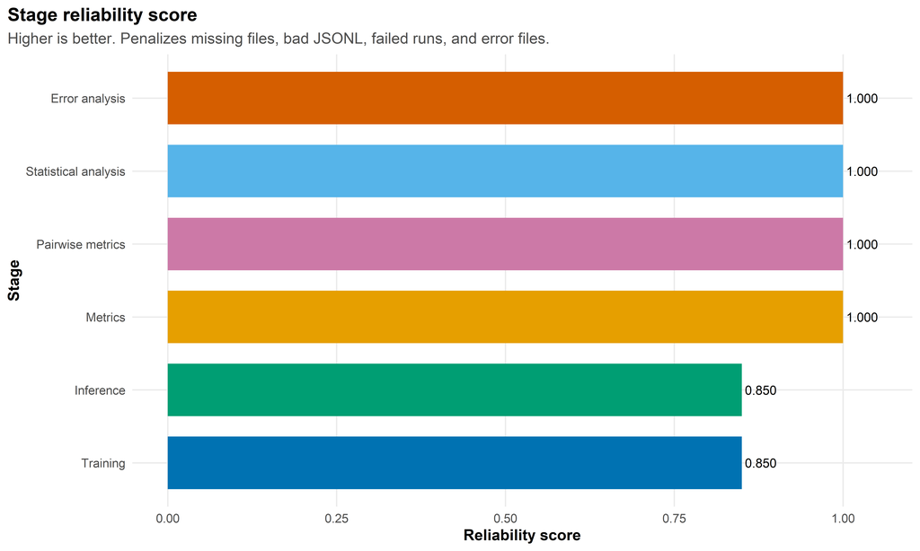

```r
p_stage_score <- stage_scorecard |>
  ggplot(aes(x = fct_reorder(stage_label, reliability_score), y = reliability_score, fill = stage)) +
  geom_col(width = 0.72, show.legend = FALSE) +
  geom_text(
    aes(label = scales::number(reliability_score, accuracy = 0.001)),
    hjust = -0.1,
    size = 3.5
  ) +
  coord_flip() +
  scale_fill_manual(values = stage_palette, drop = FALSE) +
  scale_y_continuous(limits = c(0, 1.05)) +
  labs(
    title = "Stage reliability score",
    subtitle = "Higher is better. Penalizes missing files, bad JSONL, failed runs, and error files.",
    x = "Stage",
    y = "Reliability score"
  ) +
  base_theme()

print(p_stage_score)
```

```r
save_rel_figure(
  p_stage_score,
  "01_stage_reliability_score.png",
  width = 10,
  height = 6
)
```

## 14.2 Scenario reliability score

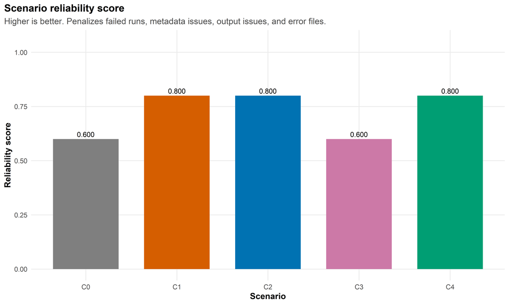

```r
p_scenario_score <- scenario_scorecard |>
  ggplot(aes(x = scenario_short, y = reliability_score, fill = scenario_short)) +
  geom_col(width = 0.72, show.legend = FALSE) +
  geom_text(
    aes(label = scales::number(reliability_score, accuracy = 0.001)),
    vjust = -0.4,
    size = 3.5
  ) +
  scale_fill_manual(values = scenario_palette, drop = FALSE) +
  scale_y_continuous(limits = c(0, 1.05)) +
  labs(
    title = "Scenario reliability score",
    subtitle = "Higher is better. Penalizes failed runs, metadata issues, output issues, and error files.",
    x = "Scenario",
    y = "Reliability score"
  ) +
  base_theme()

print(p_scenario_score)
```

```r
save_rel_figure(
  p_scenario_score,
  "02_scenario_reliability_score.png",
  width = 10,
  height = 6
)
```

## 14.3 Event counts by stage

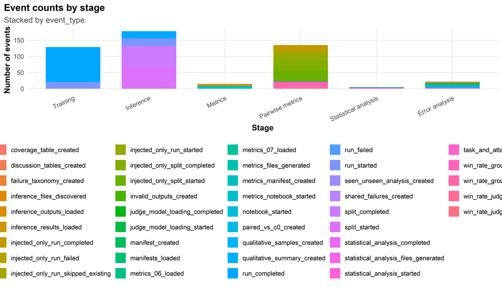

```r
if (nrow(event_type_summary) > 0) {
  p_event_counts <- event_type_summary |>
    ggplot(aes(x = stage_label, y = n_events, fill = event_type)) +
    geom_col(width = 0.72) +
    labs(
      title = "Event counts by stage",
      subtitle = "Stacked by event_type.",
      x = "Stage",
      y = "Number of events",
      fill = "Event type"
    ) +
    base_theme() +
    theme(axis.text.x = element_text(angle = 25, hjust = 1))

  print(p_event_counts)

  save_rel_figure(
    p_event_counts,
    "03_event_counts_by_stage.png",
    width = 10.5,
    height = 6
  )
}
```

## 14.4 Bad JSONL lines by stage

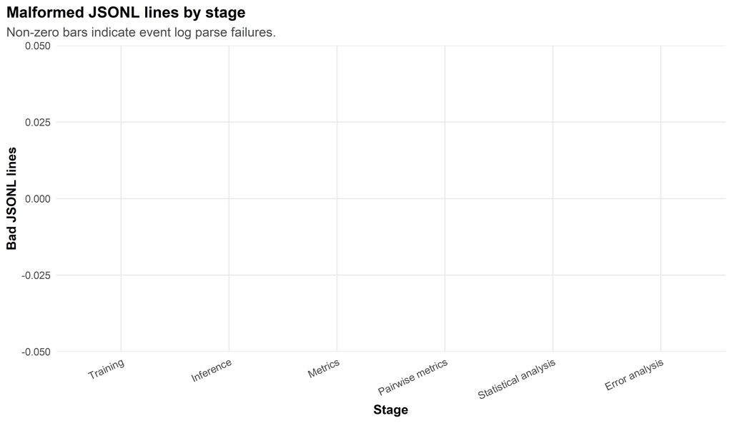

```r
p_bad_jsonl <- event_integrity_summary |>
  ggplot(aes(x = stage_label, y = bad_jsonl_lines, fill = stage)) +
  geom_col(width = 0.72, show.legend = FALSE) +
  scale_fill_manual(values = stage_palette, drop = FALSE) +
  labs(
    title = "Malformed JSONL lines by stage",
    subtitle = "Non-zero bars indicate event log parse failures.",
    x = "Stage",
    y = "Bad JSONL lines"
  ) +
  base_theme() +
  theme(axis.text.x = element_text(angle = 25, hjust = 1))

print(p_bad_jsonl)
```

```r
save_rel_figure(
  p_bad_jsonl,
  "04_bad_jsonl_lines_by_stage.png",
  width = 9.5,
  height = 5.5
)
```

## 14.5 Run status by stage

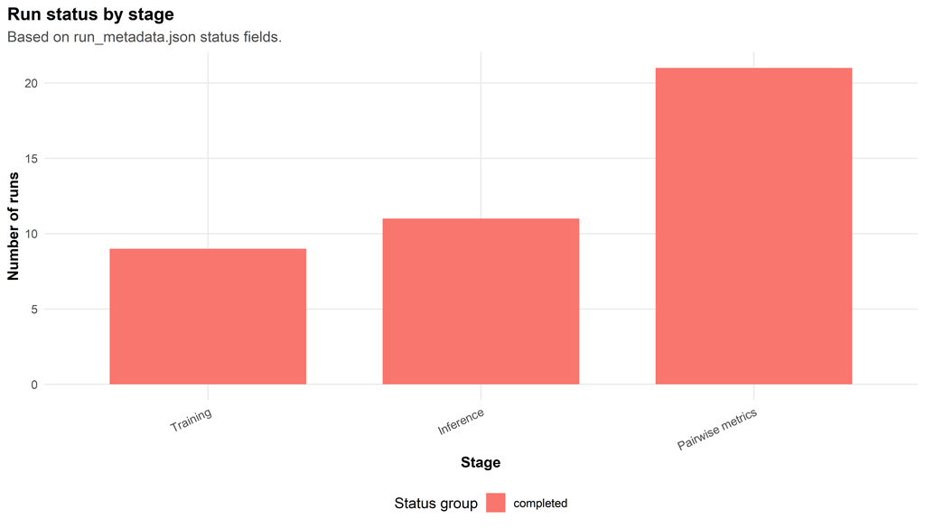

```r
if (nrow(run_status_summary) > 0) {
  p_run_status <- run_status_summary |>
    ggplot(aes(x = stage_label, y = n_runs, fill = status_group)) +
    geom_col(width = 0.72) +
    labs(
      title = "Run status by stage",
      subtitle = "Based on run_metadata.json status fields.",
      x = "Stage",
      y = "Number of runs",
      fill = "Status group"
    ) +
    base_theme() +
    theme(axis.text.x = element_text(angle = 25, hjust = 1))

  print(p_run_status)

  save_rel_figure(
    p_run_status,
    "05_run_status_by_stage.png",
    width = 10.5,
    height = 6
  )
}
```

## 14.6 Error categories

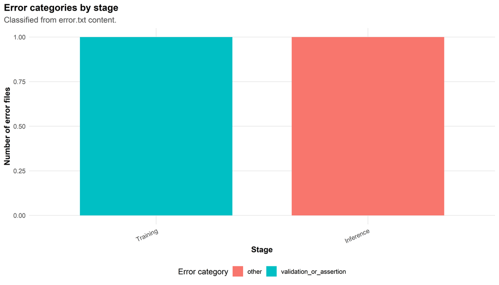

```r
if (nrow(error_category_summary) > 0) {
  p_error_categories <- error_category_summary |>
    group_by(stage, stage_label, error_category) |>
    summarise(n_error_files = sum(n_error_files), .groups = "drop") |>
    ggplot(aes(x = stage_label, y = n_error_files, fill = error_category)) +
    geom_col(width = 0.72) +
    labs(
      title = "Error categories by stage",
      subtitle = "Classified from error.txt content.",
      x = "Stage",
      y = "Number of error files",
      fill = "Error category"
    ) +
    base_theme() +
    theme(axis.text.x = element_text(angle = 25, hjust = 1))

  print(p_error_categories)

  save_rel_figure(
    p_error_categories,
    "06_error_categories_by_stage.png",
    width = 10.5,
    height = 6
  )
}
```

## 14.7 Metadata issues by stage

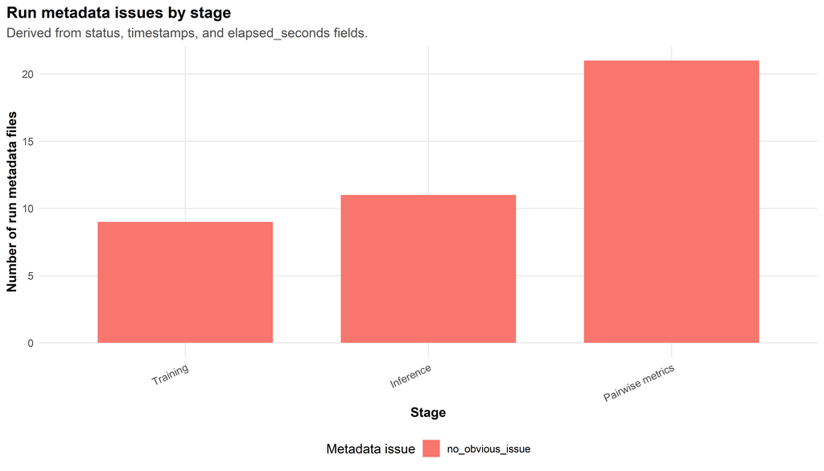

```r
if (nrow(run_metadata_issue_summary) > 0) {
  p_metadata_issues <- run_metadata_issue_summary |>
    ggplot(aes(x = stage_label, y = n_runs, fill = metadata_issue)) +
    geom_col(width = 0.72) +
    labs(
      title = "Run metadata issues by stage",
      subtitle = "Derived from status, timestamps, and elapsed_seconds fields.",
      x = "Stage",
      y = "Number of run metadata files",
      fill = "Metadata issue"
    ) +
    base_theme() +
    theme(axis.text.x = element_text(angle = 25, hjust = 1))

  print(p_metadata_issues)

  save_rel_figure(
    p_metadata_issues,
    "07_run_metadata_issues_by_stage.png",
    width = 10.5,
    height = 6
  )
}
```

## 14.8 Split issues by scenario

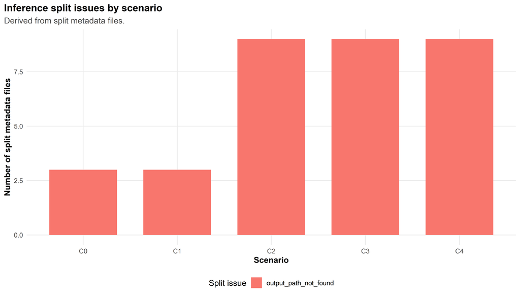

```r
if (nrow(split_issue_summary) > 0) {
  p_split_issues <- split_issue_summary |>
    group_by(scenario_short, split_issue) |>
    summarise(n_split_metadata_files = sum(n_split_metadata_files), .groups = "drop") |>
    ggplot(aes(x = scenario_short, y = n_split_metadata_files, fill = split_issue)) +
    geom_col(width = 0.72) +
    labs(
      title = "Inference split issues by scenario",
      subtitle = "Derived from split metadata files.",
      x = "Scenario",
      y = "Number of split metadata files",
      fill = "Split issue"
    ) +
    base_theme()

  print(p_split_issues)

  save_rel_figure(
    p_split_issues,
    "08_split_issues_by_scenario.png",
    width = 10.5,
    height = 6
  )
}
```

## 14.9 Reliability heatmap

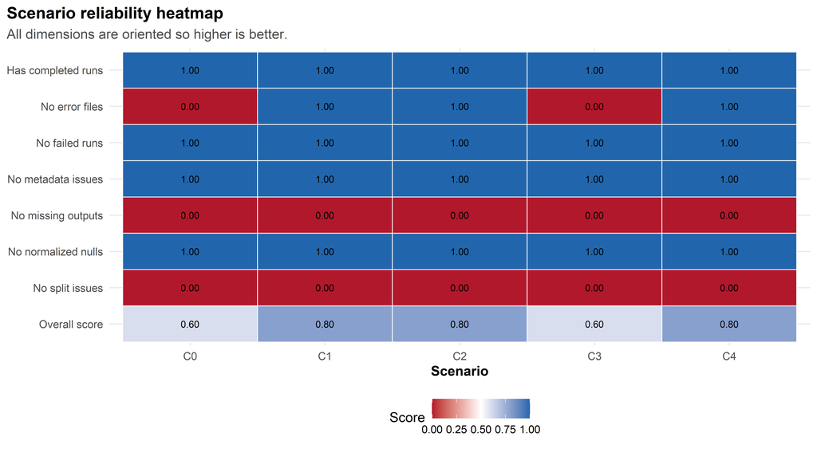

```r
scenario_heatmap <- scenario_scorecard |>
  select(
    scenario_short,
    completed_runs,
    failed_runs,
    metadata_issues,
    split_issues,
    output_missing_count,
    normalized_null_issue_count,
    error_files,
    reliability_score
  ) |>
  mutate(
    completed_runs_score = ifelse(completed_runs > 0, 1, 0),
    failed_runs_score = 1 - pmin(failed_runs, 1),
    metadata_issues_score = 1 - pmin(metadata_issues, 1),
    split_issues_score = 1 - pmin(split_issues, 1),
    output_missing_score = 1 - pmin(output_missing_count, 1),
    normalized_null_score = 1 - pmin(normalized_null_issue_count, 1),
    error_files_score = 1 - pmin(error_files, 1)
  ) |>
  select(
    scenario_short,
    completed_runs_score,
    failed_runs_score,
    metadata_issues_score,
    split_issues_score,
    output_missing_score,
    normalized_null_score,
    error_files_score,
    reliability_score
  ) |>
  pivot_longer(
    cols = -scenario_short,
    names_to = "dimension",
    values_to = "score"
  ) |>
  mutate(
    dimension = recode(
      dimension,
      completed_runs_score = "Has completed runs",
      failed_runs_score = "No failed runs",
      metadata_issues_score = "No metadata issues",
      split_issues_score = "No split issues",
      output_missing_score = "No missing outputs",
      normalized_null_score = "No normalized nulls",
      error_files_score = "No error files",
      reliability_score = "Overall score"
    )
  )

p_reliability_heatmap <- scenario_heatmap |>
  ggplot(aes(x = scenario_short, y = fct_rev(factor(dimension)), fill = score)) +
  geom_tile(color = "white", linewidth = 0.35) +
  geom_text(aes(label = scales::number(score, accuracy = 0.01)), size = 3) +
  scale_fill_gradient2(
    low = "#B2182B",
    mid = "white",
    high = "#2166AC",
    midpoint = 0.5,
    limits = c(0, 1)
  ) +
  labs(
    title = "Scenario reliability heatmap",
    subtitle = "All dimensions are oriented so higher is better.",
    x = "Scenario",
    y = NULL,
    fill = "Score"
  ) +
  base_theme()

print(p_reliability_heatmap)
```

```r
save_rel_figure(
  p_reliability_heatmap,
  "09_scenario_reliability_heatmap.png",
  width = 10,
  height = 5.5
)
```

## 14.10 Event timeline

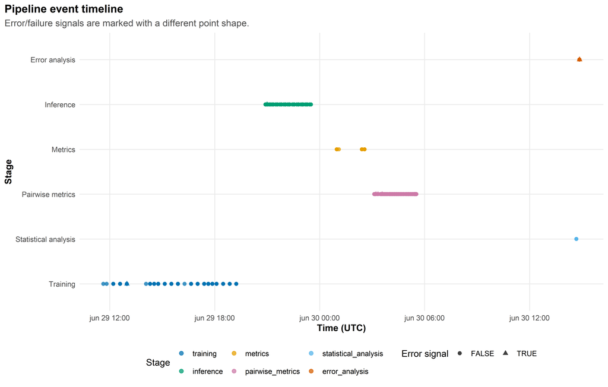

```r
if (nrow(all_events) > 0) {
  timeline_events <- all_events |>
    filter(!is.na(timestamp)) |>
    mutate(
      stage_label_chr = as.character(stage_label),
      point_alpha = ifelse(event_has_error_signal, 1, 0.65)
    )

  p_event_timeline <- timeline_events |>
    ggplot(aes(x = timestamp, y = fct_rev(stage_label_chr), color = stage)) +
    geom_point(aes(shape = event_has_error_signal), alpha = 0.75, size = 2.2) +
    scale_color_manual(values = stage_palette, drop = FALSE) +
    labs(
      title = "Pipeline event timeline",
      subtitle = "Error/failure signals are marked with a different point shape.",
      x = "Time (UTC)",
      y = "Stage",
      color = "Stage",
      shape = "Error signal"
    ) +
    base_theme()

  print(p_event_timeline)

  save_rel_figure(
    p_event_timeline,
    "10_pipeline_event_timeline.png",
    width = 11,
    height = 7
  )
}
```

# 15 Paper-ready reliability table

```r
paper_reliability_table <- scenario_scorecard |>
  select(
    scenario_short,
    run_metadata_files,
    completed_runs,
    failed_runs,
    run_success_rate,
    metadata_issues,
    split_metadata_files,
    split_issues,
    output_missing_count,
    normalized_null_issue_count,
    error_files,
    reliability_score,
    reliability_label
  ) |>
  mutate(
    run_success_rate = fmt_pct(run_success_rate),
    reliability_score = fmt_number(reliability_score, accuracy = 0.001)
  )

write_rel_csv(paper_reliability_table, "21_paper_ready_reliability_table.csv")

paper_reliability_table |>
  knitr::kable(
    caption = "Table 17 - Paper-ready reliability table."
  )
```

Table 17 - Paper-ready reliability table.

| scenario_short | run_metadata_files | completed_runs | failed_runs | run_success_rate | metadata_issues | split_metadata_files | split_issues | output_missing_count | normalized_null_issue_count | error_files | reliability_score | reliability_label |
| --- | --- | --- | --- | --- | --- | --- | --- | --- | --- | --- | --- | --- |
| C0 | 2 | 2 | 0 | 100.0% | 0 | 3 | 3 | 3 | 0 | 1 | 0.600 | low |
| C1 | 3 | 3 | 0 | 100.0% | 0 | 3 | 3 | 3 | 0 | 0 | 0.800 | medium |
| C2 | 12 | 12 | 0 | 100.0% | 0 | 9 | 9 | 9 | 0 | 0 | 0.800 | medium |
| C3 | 12 | 12 | 0 | 100.0% | 0 | 9 | 9 | 9 | 0 | 1 | 0.600 | low |
| C4 | 12 | 12 | 0 | 100.0% | 0 | 9 | 9 | 9 | 0 | 0 | 0.800 | medium |

# 16 Interpretation notes

```r
cat("
## How to interpret this report

This report separates three types of reliability evidence.

First, event-log integrity checks whether JSONL logs can be parsed and whether stages emitted start, completion, or failure events.

Second, metadata reliability checks run_metadata.json and split metadata files for missing timestamps, missing elapsed time, failed statuses, missing outputs, and normalized-null counts.

Third, error-file analysis searches for error.txt files and classifies their content into broad failure categories.

The reliability score is a compact diagnostic score. It is not a statistical estimate. It is useful for comparing operational health across stages and scenarios, but the detailed tables should be used to explain the concrete failure modes.
")
```

## 16.1 How to interpret this report

This report separates three types of reliability evidence.

First, event-log integrity checks whether JSONL logs can be parsed and whether stages emitted start, completion, or failure events.

Second, metadata reliability checks run_metadata.json and split metadata files for missing timestamps, missing elapsed time, failed statuses, missing outputs, and normalized-null counts.

Third, error-file analysis searches for error.txt files and classifies their content into broad failure categories.

The reliability score is a compact diagnostic score. It is not a statistical estimate. It is useful for comparing operational health across stages and scenarios, but the detailed tables should be used to explain the concrete failure modes.

# 17 Generated files

Tables are saved in:

```
tables/reliability_failure_analysis/
```

Figures are saved in:

```
figures/reliability_failure_analysis/
```

Main files:

```
01_stage_file_inventory.csv
02_all_events_enriched.csv
03_bad_jsonl_lines.csv
04_event_integrity_summary.csv
05_event_type_summary.csv
06_event_scenario_seed_summary.csv
07_metadata_inventory.csv
08_metadata_inventory_summary.csv
09_run_metadata_reliability.csv
10_run_status_summary.csv
11_run_metadata_issue_summary.csv
12_split_metadata_reliability.csv
13_split_issue_summary.csv
14_split_coverage_summary.csv
15_pipeline_error_files_classified.csv
16_error_category_summary.csv
17_expected_training_run_coverage.csv
18_expected_inference_run_coverage.csv
19_stage_reliability_scorecard.csv
20_scenario_reliability_scorecard.csv
21_paper_ready_reliability_table.csv

01_stage_reliability_score.png
02_scenario_reliability_score.png
03_event_counts_by_stage.png
04_bad_jsonl_lines_by_stage.png
05_run_status_by_stage.png
06_error_categories_by_stage.png
07_run_metadata_issues_by_stage.png
08_split_issues_by_scenario.png
09_scenario_reliability_heatmap.png
10_pipeline_event_timeline.png
```